# How to Use the **autoimage** package

Joshua P. French

2017-02-23

## Introduction

The **autoimage** package makes it easy to plot a sequence of images with corresponding color scales, i.e., a sequence of heatmaps, with straightforward, native options for projection of geographical coordinates. The package makes it simple to add lines, points, and other features to the images, even when the coordinates are projected. The package allows for seamless creation of heat maps for data on regular or irregular grids, as well as data that is not on a grid.

## Examples

The most important functions in **autoimage** are the `pimage` and `autoimage` functions. We illustrate the basic usage of these functions using two data sets: the first is data on an irregular grid and the second is non-gridded data.

The first data set we utilize comes from the North American Regional Climate Change Assessment Program (NARCCAP, http://www.narccap.ucar.edu/). Specifically, the data are the maximum daily surface air temperature (K) (abbreviated tasmax) for the five consecutive days of May 15, 2041 to May 19, 2041 simulated using the Canadian Regional Climate Model (Caya and Laprise, 1999) forced by the Community Climate System Model atmosphere-ocean general circular model (Collins et al., 2006). The data set contains `lon`, a 140 $\times$ 115 matrix of longitude coordinates, `lat`, a 140 $\times$ 115 matrix of latitude coordinates, and `tasmax`, a 140 $\times$ 115 $\times$ 5 array, where each element of the third dimension of the array corresponds to the `tasmax` measurements of the respective day.

The second data set we utilize is geochemical measurements obtained by the United States Geological Survey (USGS) in the state of Colorado. The data are stored as a data frame with 960 rows and 31 columns. `easting`, `northing`, `latitude`, and `longitude` variables are provided in the data frame, as well as Aluminum (`Al`), Calcium (`Ca`), Iron (`Fe`), and many more chemical measurements.

The `autoimage` function is a generalization of the `pimage` function, so we discuss the `pimage` function first.

### Basic usage of `pimage`

The most important arguments of the `pimage` function are `x`, `y`, and `z`. `x` and `y` are the coordinate locations and `z` is the responses associated with the coordinates.

We create a basic image plot by providing `x`, `y`, and `z` to the `pimage` function.

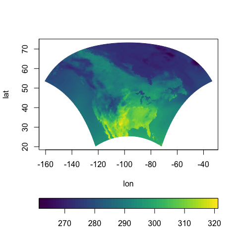

```r
data(narccap)
pimage(x = lon, y = lat, z = tasmax[,,1])
```

`x`, `y`, and `z` can have differing formats depending on the type of data. **If the data are observed on a regular grid**, then `z` will be matrix with dimensions matching the dimensions of the grid and `x` and `y` will be vectors of increasing values that define the grid lines. **If the data are observed on an irregular grid** (e.g., a regular grid that is rotated or projected), then `z` will be a matrix matching with dimensions matching the dimensions of the grid and `x` and `y` will be matrices whose coordinates specify the x and y coordinates of each value in `z`. If the data are not on a grid, then `x` and `y` will be vectors specifying the coordinate locations and `z` will be the vector of responses at each coordinate. If the data are not on a grid, then the data are automatically interpolated onto a grid before plotting.

We create a heat map using the non-gridded Aluminum measurements for the state of Colorado.

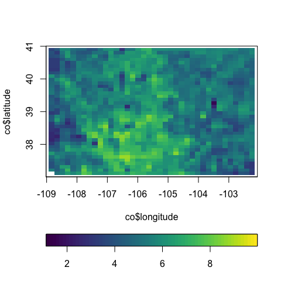

```r
data(co, package = "gear")
pimage(co$longitude, co$latitude, co$Al)
```

We now discuss the basic options of the `pimage` function.

The color scheme used for an image plot can be of great importance. The `viridis` color scheme from the **viridis** package is used by default as it is, “… designed in such a way that [it] will analytically be perfectly perceptually-uniform, both in regular form and also when converted to black-and-white. [It is] also designed to be perceived by readers with the most common form of color blindness.” The colors of the color scale can be modified by passing a vector of colors to the `col` argument through `...`, as in the `image` function in **graphics**. We use 6 colors from the `magma` color palette in the **viridis** package in the next example.

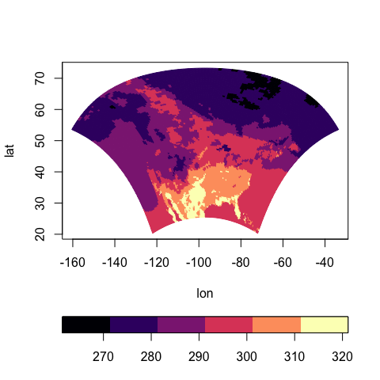

```r
pimage(lon, lat, tasmax[,,1], col = viridis::magma(6))
```

The orientation of the color scale can be changed by changing the `legend` argument. The default is `legend = "horizontal"`. The color scale can be removed by specifying `legend = "none"` or rotated to a vertical orientation by specifying `legend = "vertical"`.

The following code creates a heat map with a vertical color scale.

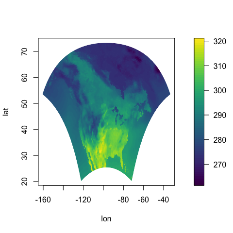

```r
pimage(x = lon, y = lat, z = tasmax[,,1], legend = "vertical")
```

The longitude and latitude coordinates can be projected before plotting by specifying the `proj`, `parameters`, and `orientation` arguments of `pimage`. Prior to plotting, the coordinates are projected using the `mapproject` function in the **mapproj** package. `proj` specifies the name of the projection to utilize (the default is `"none"`). The `parameters` argument specifies the parameter values of the chosen projection and `orientation` can be used to change the orientation of the projection. See the `mapproject` function in the **mapproj** function for more details regarding these arguments.

We now create a heat map with projected coordinates. We will utilize the Bonne projection using 45 degrees as the standard parallel. A grid is automatically added to projected images because latitude and longitude parallels are not straight for most projections.

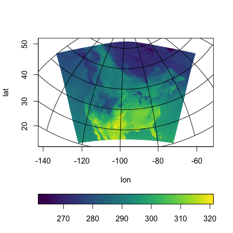

```r
pimage(x = lon, y = lat, z = tasmax[,,1], proj = "bonne",
       parameters = 45)
```

Several maps can be automatically added to the image by specifying the `map` argument. The maps come from the **maps** package, and include the `world`, `usa`, `state`, `county`, `france`, `nz` (New Zealand), `italy`, `lakes`, and `world2` maps.

We add national boundaries to our previous map.

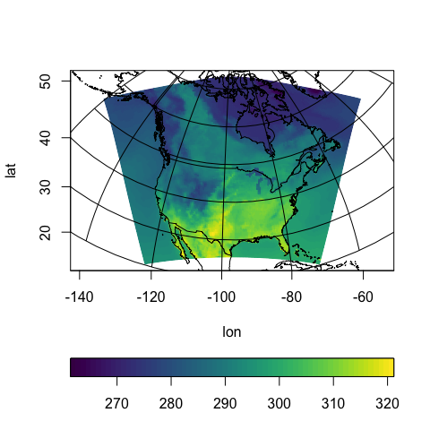

```r
pimage(x = lon, y = lat, z = tasmax[,,1], proj = "bonne",
       parameters = 45, map = "world")
```

The last major argument to the `pimage` function is the `lratio` argument. This argument controls the relative height or width of the color scale in comparison with the main plotting area. Increasing `lratio` increases the thickness of the color scale, while decreasing `lratio` decreases the thickness of the color scale.

Additional arguments can be passed to the `pimage` function via `...`. These will be discussed at a later time in this vignette.

### Basic use of `autoimage`

The `autoimage` function generalizes the `pimage` function to allow for multiple images in the same plot. Most of the arguments are the same as the `pimage` function, and we do not replicate their discussion except when necessary.

The structure of `z` will vary slightly from the `pimage` function. Specifically, if multiple gridded images are to be constructed, then `z` will be a three-dimensional array instead of a matrix. Each element of the third dimension of `z` corresponds to the matrix of gridded values for each image. If images for multiple non-gridded variables are to be constructed, then `z` will be a matrix with each column corresponding to a different variable.

Passing a three-dimensional array to `autoimage` constructs a sequence of images with a common legend. Note that we increase `lratio` to produce a more sensible legend thickness.

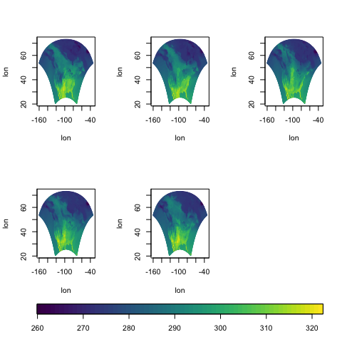

```r
autoimage(lon, lat, tasmax, lratio = 0.25)
```

Passing a two-dimensional matrix for `z` (where the number of rows matches the length of `x` and `y`) constructs a sequence of images for non-gridded data with a common legend. Titles are added to each image using the `main` argument by providing a character vector whose length matches the number of plotted images.

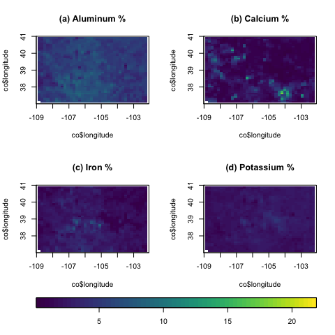

```r
autoimage(co$longitude, co$latitude, co[,c("Al", "Ca", "Fe", "K")],
           lratio = 0.25,
           main = c("(a) Aluminum %", "(b) Calcium %",
                    "(c) Iron %", "(d) Potassium %"))
```

Separate color scales will be used for each image when `common.legend = FALSE`.

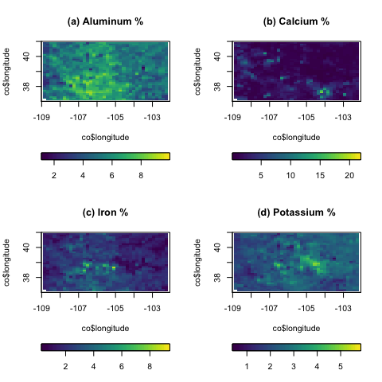

```r
autoimage(co$longitude, co$latitude, co[,c("Al", "Ca", "Fe", "K")],
          common.legend = FALSE, lratio = 0.25,
          main = c("(a) Aluminum %", "(b) Calcium %",
                   "(c) Iron %", "(d) Potassium %"))
```

The dimensions of the plotting matrix can be changed by specifying the `size` argument. If not provided, then a sensible choice is automatically chosen via the `autosize` function. The `size` argument should be a two-dimensional vector where the first element corresponds to the number of rows of images and the second dimension corresponds to the number of columns.

We create a 1 $\times$ 5 matrix of images for the NARCCAP data.

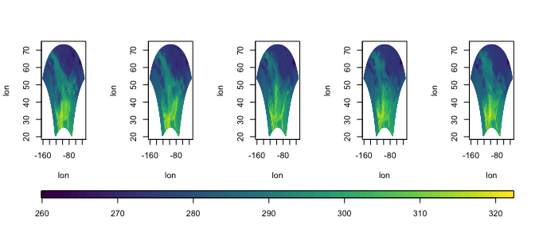

```r
autoimage(lon, lat, tasmax, size = c(1, 5))
```

A common title is sometimes desired for a sequence of images. This can easily be added by specifying the `outer.title` argument. The margins of the common title can be controlled via the `oma` argument of `par`. However, if `oma` is not specified beforehand, then a sensible value is automatically chosen (while showing a warning to the user.)

We add a common title to the NARCCAP data.

```
## Warning in autolayout(size, legend = legend, common.legend = common.legend, : There is no room in the outer margin for an outer title.
##   Setting par(oma = c(0, 0, 3, 0)).
```

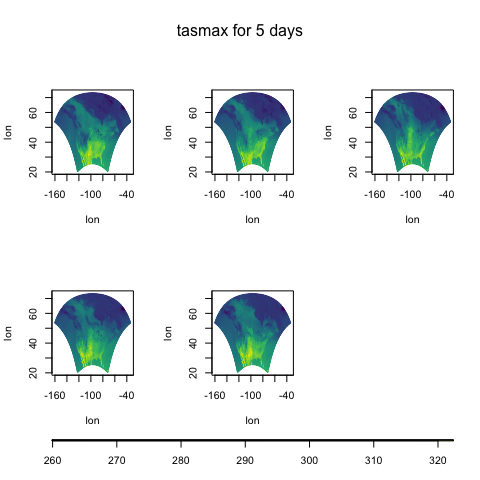

```r
autoimage(lon, lat, tasmax, outer.title = "tasmax for 5 days")
```

### Richer plots using `autolayout` and `autolegend`

Suppose we want to add custom features to a sequences of images, with each image receiving different features. One can create a richer sequence of images using the `autolayout` and `autolegend` functions.

The `autolayout` function partitions the graphic device into the sections needed to create a sequence of images. The most important function arguments include `size`, `legend`, `common.legend`, and `lratio`, which correspond to the same arguments in the `autoimage` function. The `outer` argument specifies whether an `outer.title` is desired. The default is `FALSE`. By default, numbers identify the plotting order of the sections, though these can be hidden by setting `show = FALSE`. As an initial example, we create a 2 $\times$ 3 grid of images with a common vertical legend.

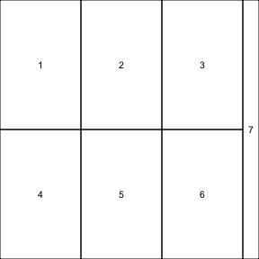

```r
autolayout(c(2, 3), legend = "v")
```

The images should be created using the `pimage` function while specifying `legend = "none"`. After the desired image or set of images is created, one can automatically add the appropriate legend by calling `autolegend`. The `autolegend` function recovers relevant legend parameters from the most recent `pimage` call. Consequently, if a common legend is desired, then it is important to specify a common `zlim` argument among all relevant `pimage` calls.

Various features can be added to the images using the `ppoints`, `plines`, `ptext`, `psegments`, `parrows`, and `ppolygon` functions. These are analogues of the `points`, `lines`, `text`, `segments`, `arrows`, and `polygon` functions in the **graphics** package, to be used with images containing projected coordinates.

We now create a complicated (though unrealistic) example of this. We first extract the borders of Hawaii and Alaska from the `"world"` map in the **maps** package and store it as the `hiak` list. We then select a small subset of cities in Colorado from the `us.cities` dataset in the **maps** package and store this in the `codf` data frame. Lastly, we select the U.S. capitals from the `us.cities` dataset and store this in the `capdf` data frame.

```r
# load world map
data(worldMapEnv, package = "maps")
# extract hawaii and alaskan borders
hiak <- maps::map("world", c("USA:Hawaii", "USA:Alaska"),
                  plot = FALSE)
# load us city information
data(us.cities, package = "maps")
# extract colorado cities from us.cities
codf <- us.cities[us.cities$country.etc == "CO", ]
# select smaller subset of colorado cities
codf <- codf[c(3, 5, 7:11, 15, 18), ]
# extract capitals from us.cities
capdf <- us.cities[us.cities$capital == 2,]
```

Having obtained the relevant information, we setup a 1 $\times$ 2 matrix of images with individual horizontal legends and an area for a common title. We create an image plot of NARCCAP data using the mercator projection and including grey state borders. The borders of Hawaii and Alaska are added using the `plines` function. The state capitals are added to the image using the `ppoints` function. The first image is then titled using the `title` function. The legend is then added using the `autolegend` function. Next, an image of the Colorado Aluminum measurements is created. The coordinates are projected using the Bonne projection, the color scheme is customized, grey county borders are added to the plot, but the grid lines are removed. The `ppoints` function is then used to add locations for several Colorado cities to the image. The `ptext` function is then used to add the names of these cities to the image. The second image is then titled using the `title` function. The appropriate legend is then added using the `autolegend` function. Lastly, a common title is added using the `mtext` function.

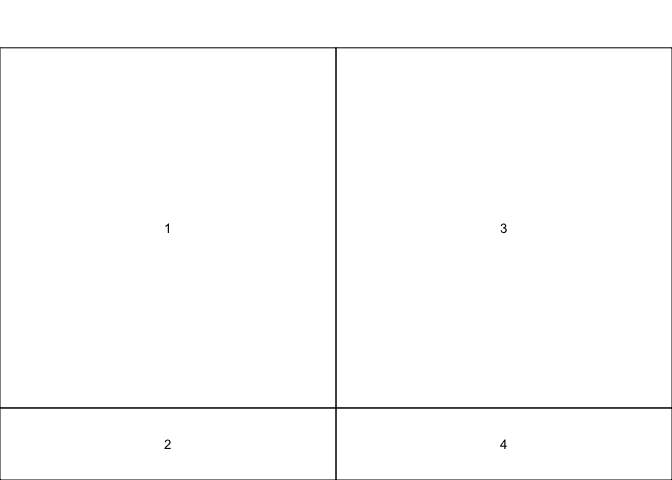

```r
# setup plotting area
autolayout(c(1, 2), legend = "h", common.legend = FALSE, outer = TRUE)
```

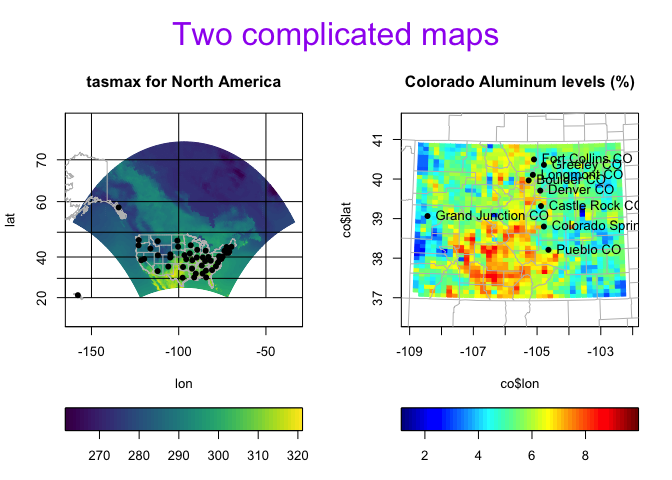

```r
# create image of NARCCAP data.
# xlim is chosen so to include alaska and hawaii
# add grey state borders
pimage(lon, lat, tasmax[,,1], legend = "none", proj = "mercator",
       map = "state", xlim = c(-180, 20),
       lines.args = list(col = "grey"))
# add hawaii and alaskan borders
plines(hiak, proj = "mercator", col = "grey")
# add state captials to image
ppoints(capdf$lon, capdf$lat, proj = "mercator", pch = 16)
# title image
title("tasmax for North America")
# add legend for plot
autolegend()
# load colorado geochemical data
data(co, package = "gear")
# create image for colorado aluminum measurements
# use bonne projection
# customize legend colors
# add grey county borders
# exclude grid
pimage(co$lon, co$lat, co$Al, map = "county", legend = "none",
       proj = "bonne", parameters = 39,
       paxes.args = list(grid = FALSE),
       col = fields::tim.colors(64),
       lines.args = list(col = "grey"))
# add colorado city points to image
ppoints(codf$lon, codf$lat, pch = 16, proj = "bonne")
# add names of colorado cities to image
ptext(codf$lon, codf$lat, labels = codf$name, proj = "bonne", pos = 4)
# title plot
title("Colorado Aluminum levels (%)")
# add legend to current image
autolegend()
# add common title for plots
mtext("Two complicated maps", col = "purple", outer = TRUE, cex = 2)
```

### More advanced options in the `pimage` and `autoimage` functions

The plots generated by the `pimage` and `autoimage` functions can be customized in numerous ways by passing additional arguments through the `...` argument of the functions. The customizations are mostly the same for both functions, so we illustrate these customizations using the `pimage` function when possible for simplicity.

Lines or points can be added to each image by passing the `lines` and `points` arguments to the functions. Each argument should be a named list with `x` and `y` components specifying the coordinates to join (for `lines`) or plot for `points`. Note that if multiple unconnected lines are to be drawn, then each line should be separated by an `NA` value, similar to how maps are constructed in the **maps** package.

```r
data(stateMapEnv, package = "maps")
statepoly <- maps::map("world", plot = FALSE)
citylist <- list(x = us.cities$long, y = us.cities$lat)
```

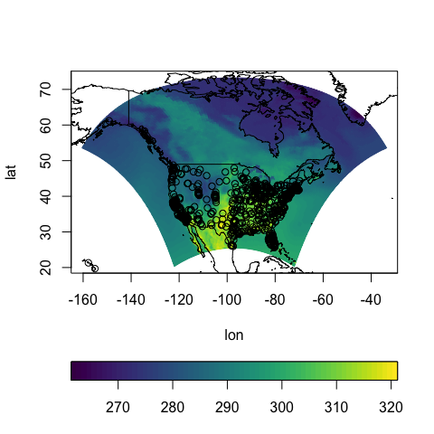

```r
pimage(lon, lat, tasmax[,,1], lines = statepoly, points = citylist)
```

The appearance of the lines and points can be customized by passing the `lines.args` and `points.args` arguments through `...`. Each argument should be a named list with components matching the arguments of the `lines` and `points` functions in the **graphics** package.

We change the appearance of the lines and points in the previous plot by specifying these arguments.

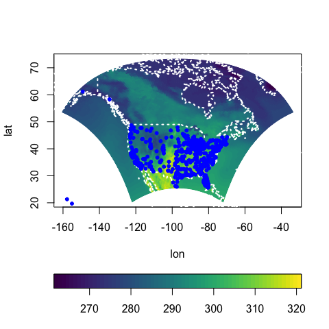

```r
pimage(lon, lat, tasmax[,,1], lines = statepoly, points = citylist,
       lines.args = list(lwd = 2, lty = 3, col = "white"),
       points.args = list(pch = 20, col = "blue"))
```

When projections are used, the grid lines do not always go as far as they should. Thus, axis customization is desired. Additionally, the appearance of the grid lines might need improving. The appears of the axis (and the locations of the grid lines) can be changed by passing `axis.args` through `...`. `axis.args` should be a named list with components matching the arguments of the `axis` function in **graphics**. The exception is that `xat` and `yat` arguments are used instead of `at` so that ticks on the x and y axes can be specified separately. The appearance of the grid lines can be changed by passing the desired changes through the `paxes.args` argument. This is a named list with options matching those in the `lines` function.

Consider the following poor graphic.

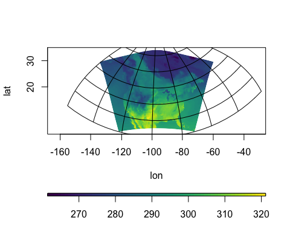

```r
pimage(lon, lat, tasmax[,,1], proj = "bonne", parameters = 40)
```

The grid lines do not extend nearly far enough. Additionally, there are only two tick marks on the y axis. We can add additional longer grid lines by specifying `xat` and `yat` in `axis.args`. We can also further change the appearance of the axes via other components of `axis.args`. We change the appearance of the grid lines by specifying choices in `paxes.args`.

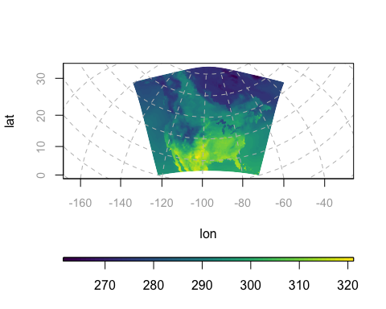

```r
pimage(lon, lat, tasmax[,,1], proj = "bonne", parameters = 40,
       axis.args = list(yat = seq(0, 70, by = 10),
                        xat = seq(-220, 20, by = 20),
                        col.axis = "darkgrey", cex.axis = 0.9),
       paxes.args = list(col = "grey", lty = 2))
```

The breaks and colors of the scale can be modified by specifying the `breaks` and `col` arguments, as in the `image` function in **graphics**. Additional changes can be made by specifying `legend.axis.args`, a named list with components matching the elements of the `axis` function, which is used in creating the legend.

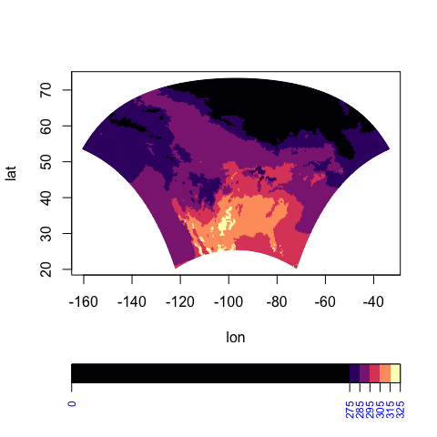

```r
pimage(lon, lat, tasmax[,,1], col = viridis::magma(6),
       breaks = c(0, 275, 285, 295, 305, 315, 325),
       legend.axis.args = list(col.axis = "blue", las = 2, cex.axis = 0.75))
```

When non-gridded are used, the interpolation settings can be passed through `...` by specifying `interp.args`, a named list with components matching those of the `interp` function in the **akima** package. We project the Colorado Aluminum measurements onto a finer grid in the following plot.

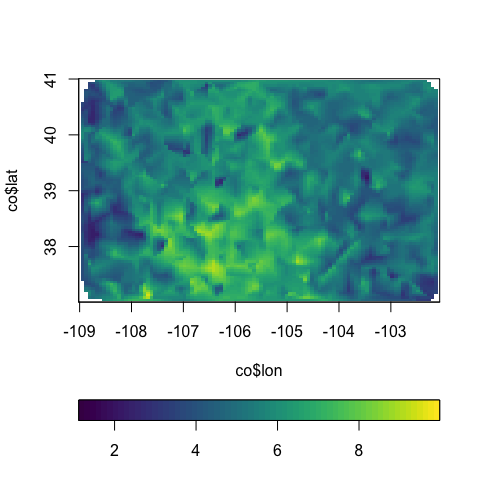

```r
pimage(co$lon, co$lat, co$Al, interp.args = list(nx = 100, ny = 100))
```

The appearance of `outer.title` can be modified by passing `mtext.args` through `...`. `mtext.args` should be a named list with components matching the elements of `mtext`, which is the function used to create the common title.

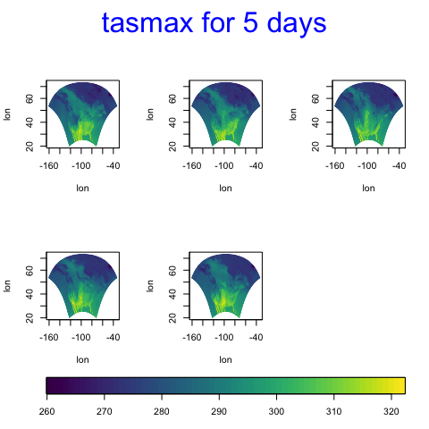

```r
autoimage(lon, lat, tasmax, outer.title = "tasmax for 5 days",
          mtext.args = list(col = "blue", cex = 2),
          lratio = 0.3)
```

## References

Mearns, L.O., et al., 2007, updated 2012. The North American Regional Climate Change Assessment Program dataset, National Center for Atmospheric Research Earth System Grid data portal, Boulder, CO. Data downloaded 2016-08-12. http://dx.doi.org/10.5065/D6RN35ST.

Mearns, L. O., W. J. Gutowski, R. Jones, L.-Y. Leung, S. McGinnis, A. M. B. Nunes, and Y. Qian: A regional climate change assessment program for North America. EOS, Vol. 90, No. 36, 8 September 2009, pp. 311-312.

D. Caya and R. Laprise. A semi-implicit semi-Lagrangian regional climate model: The Canadian RCM. Monthly Weather Review, 127(3):341–362, 1999.

M. Collins, B. B. Booth, G. R. Harris, J. M. Murphy, D. M. Sexton, and M. J. Webb. Towards quantifying uncertainty in transient climate change. Climate Dynamics, 27(2-3):127–147, 2006. http://dx.doi.org/10.1007/s00382-006-0121-0.